# Reproducible Research: Peer Assessment 1

## Loading and preprocessing the data

```r
activityDataSet <- read.csv("activity.csv", header = TRUE)

#convert the date column to a more handy format
activityDataSet$date <- as.Date(activityDataSet$date, "%Y-%m-%d")

sapply(activityDataSet, class)
```

```
##     steps      date  interval
## "integer"    "Date" "integer"
```

```r
head(activityDataSet)
```

```
##   steps       date interval
## 1    NA 2012-10-01        0
## 2    NA 2012-10-01        5
## 3    NA 2012-10-01       10
## 4    NA 2012-10-01       15
## 5    NA 2012-10-01       20
## 6    NA 2012-10-01       25
```

Looks like we’re good to go, besides the NA values on the columns STEPS, but more on that later in the assigment.

## What is mean total number of steps taken per day?

This part uses very simple functions such as: sum, mean and median; However, since we didn’t fix the NA values on the data set, we need to use ( for now ), na.rm = TRUE, so we can calculate what we want, without being bothered by NA.

- Calculate the total number of steps taken per day, and to do this we use:

```r
totalNumberStepsPerDayBeforeNA <- as.data.frame.table(tapply(activityDataSet$steps,activityDataSet[,2],sum,na.rm = TRUE))
```

- If you do not understand the difference between a histogram and a barplot, research the difference between them. Make a histogram of the total number of steps taken each day

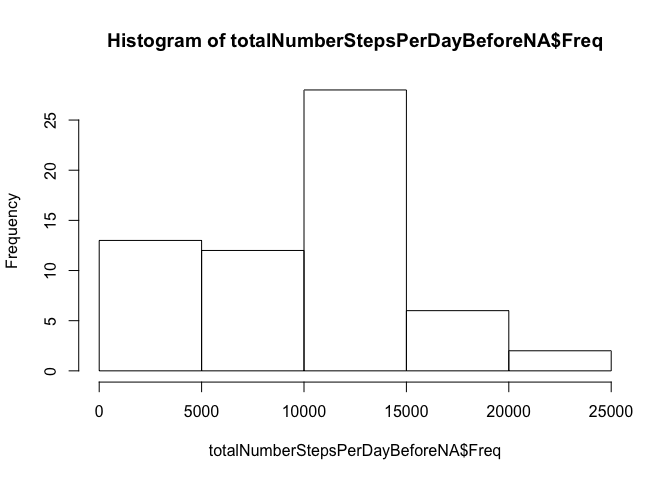

```r
hist(totalNumberStepsPerDayBeforeNA$Freq)
```

- Calculate and report the mean and median of the total number of steps taken per day
- Mean

  ```r
    mean(totalNumberStepsPerDayBeforeNA$Freq, na.rm = TRUE)
  ```

  ```
  ## [1] 9354.23
  ```

- Median

  ```r
    median(totalNumberStepsPerDayBeforeNA$Freq, na.rm = TRUE)
  ```

  ```
  ## [1] 10395
  ```

## What is the average daily activity pattern?

- Time series plot for the average number of Steps taken across all days crossed with the intervals

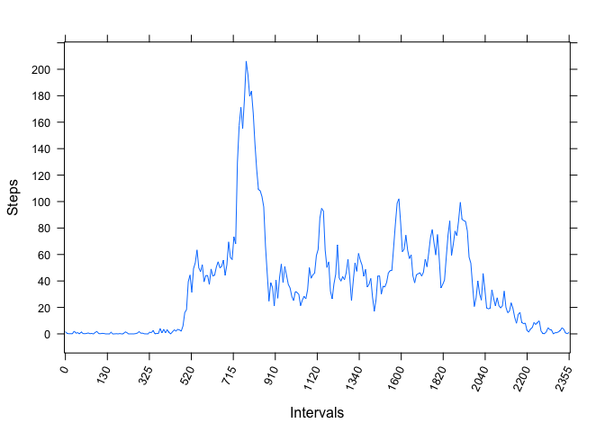

```r
#credits to http://stackoverflow.com/questions/4683242/calculating-a-daily-mean-in-r
#credits to http://r.789695.n4.nabble.com/How-to-quot-flatten-quot-a-multidimensional-array-into-a-dataframe-td4572108.html
part2 <- as.data.frame.table(tapply(activityDataSet$steps,activityDataSet[,3],mean,na.rm = TRUE))

library(lattice)

#credits to http://stackoverflow.com/questions/21711479/reduce-tick-marks-in-xyplot-in-r
## calculate position and create labels
x.tick.number <- 13
at <- seq(1, nrow(part2), length.out=x.tick.number)


labelInterval <- factor(c(0, 130, 325, 520, 715, 910, 1120, 1340, 1600, 1820, 2040, 2200, 2355))
xyplot(Freq ~  Var1, type = "l",data=part2, scales=list(y=list(tick.number=10),
                                   x=list(at=at, labels=labelInterval, rot=65)), xlab = "Intervals", ylab = "Steps")
```

### Which 5-minute interval, on average across all the days in the dataset, contains the maximum number of steps

And the answer is:

```r
part2[which.max( part2[,2] ), ]
```

```
##     Var1     Freq
## 104  835 206.1698
```

Which means that at 8:35am people would usually walk 200 steps, but you saw that coming right?

## Imputing missing values

### Total number of missing values

```r
colSums(is.na(activityDataSet))
```

```
##    steps     date interval
##     2304        0        0
```

### Strategy for filling the missing values

We take a mean of the steps taken and group it by day, then add the values to the rows that contain NA(through that ugly and slow FOR nested loop, I know).

```r
fixNa <- as.data.frame.table(tapply(activityDataSet$steps,activityDataSet[, 2],mean,na.rm = TRUE))
fixNa[is.na(fixNa)] <- 0
fixNa$Var1 <- as.Date(fixNa$Var1, "%Y-%m-%d")
```

### New dataset

Now we create a new dataset without the NA values

```r
copyActivityDataSet <- activityDataSet

#partial credits to http://stackoverflow.com/questions/19379081/how-to-replace-na-values-in-a-table-for-selected-columns-data-frame-data-tab
# the other half goes to http://stackoverflow.com/questions/5965698/r-merge-unequal-dataframes-and-replace-missing-rows-with-0

for(i in 1:nrow(copyActivityDataSet))
{
    for(j in 1:nrow(fixNa)){
        if(copyActivityDataSet$date[i] == fixNa$Var1[j]){
            copyActivityDataSet[i,1][is.na(copyActivityDataSet[i, 1])] <- fixNa$Freq[j]
        }
    }
}
```

Let’s check how many NA’s now

```r
colSums(is.na(copyActivityDataSet))
```

```
##    steps     date interval
##        0        0        0
```

Looks good, let’s move on.

### Histogram , Mean and Median with the new Dataset

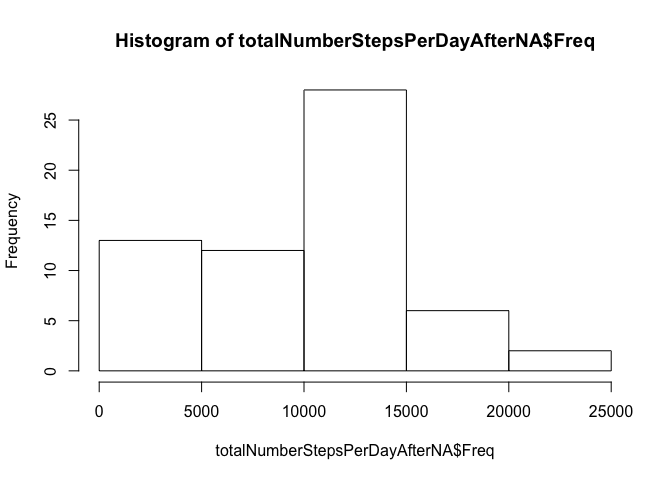

```r
totalNumberStepsPerDayAfterNA <- as.data.frame.table(tapply(copyActivityDataSet$steps,activityDataSet[,2],sum,na.rm = TRUE))

hist(totalNumberStepsPerDayAfterNA$Freq)
```

```r
mean(totalNumberStepsPerDayAfterNA$Freq)
```

```
## [1] 9354.23
```

```r
median(totalNumberStepsPerDayAfterNA$Freq)
```

```
## [1] 10395
```

### Do the values differ from part 1?

Apparently not if you simply look the values above, but let’s take a look at the sum of the columns before and after the insertion of mean steps.

```r
sum(totalNumberStepsPerDayBeforeNA$Freq)
```

```
## [1] 570608
```

```r
sum(totalNumberStepsPerDayAfterNA$Freq)
```

```
## [1] 570608
```

And the values are the same, magic? Maybe not; If you saw any mistake, please leave a feedback, I’ll appreciate very much.

## Are there differences in activity patterns between weekdays and weekends?

Let’s find out:

### Creating a New factor variable in the dataset with two levels – “weekday” and “weekend”

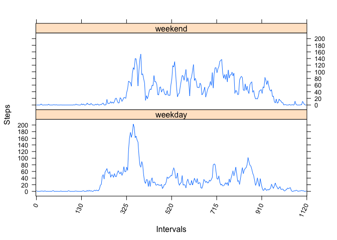

```r
#Let's create the factor for all days in the dataset
copyActivityDataSet$dayType <- ifelse((weekdays(copyActivityDataSet$date) == "Saturday" | weekdays(copyActivityDataSet$date) == "Sunday") , "weekend", "weekday")


library(lattice)
#define the new column as a factor
copyActivityDataSet <- transform(copyActivityDataSet, dayType = factor(dayType))

#Make a subset calculating the mean of steps across all days counting for Weekday or Weekend
panelPlot <- as.data.frame.table(tapply(copyActivityDataSet$steps,copyActivityDataSet[,3:4],mean,na.rm = TRUE))

#Pre process the plot
x.tick.number <- 13
at <- seq(1, nrow(panelPlot), length.out=x.tick.number)
labelIntervalWeek <- factor(c(0, 130, 325, 520, 715, 910, 1120, 1340, 1600, 1820, 2040, 2200, 2355))

xyplot(Freq ~  interval | panelPlot$dayType , type = "l",data=panelPlot, scales=list(y=list(tick.number=13),
                                   x=list(at=at, labels=labelIntervalWeek, rot=65)), xlab = "Intervals", ylab = "Steps",layout = c(1, 2))
```